# CSS_205_week_1_HW

2. Type `set.seed(10825)`. Then combine the $\mathbf{X}$ matrix you just downloaded with the linear model you described in part (a) to generate `n` simulated $y$ values. Becareful with the constant! Then regress these simulated $y$ values on $\mathbf{X}$. Display the results in a regression table.

```r
set.seed(10825)
```

```r
Xi <- data.matrix(xmat)

e <- rnorm(1000, mean = 0, sd = sqrt(1.5))

yi <- 0.5*Xi[,1] - 2.2*Xi[,2] + Xi[,3] + e + 1


regress <- lm(yi ~ Xi[,1] + Xi[,2] + Xi[,3])
summary(regress)
```

```
##
## Call:
## lm(formula = yi ~ Xi[, 1] + Xi[, 2] + Xi[, 3])
##
## Residuals:
##     Min      1Q  Median      3Q     Max
## -3.5330 -0.8196  0.0124  0.8168  4.5651
##
## Coefficients:
##             Estimate Std. Error t value Pr(>|t|)
## (Intercept)  1.06651    0.05084   20.98   <2e-16 ***
## Xi[, 1]      0.48024    0.01925   24.95   <2e-16 ***
## Xi[, 2]     -2.26451    0.07852  -28.84   <2e-16 ***
## Xi[, 3]      0.95040    0.03822   24.86   <2e-16 ***
## ---
## Signif. codes:  0 '***' 0.001 '**' 0.01 '*' 0.05 '.' 0.1 ' ' 1
##
## Residual standard error: 1.225 on 996 degrees of freedom
## Multiple R-squared:  0.6792, Adjusted R-squared:  0.6782
## F-statistic: 702.9 on 3 and 996 DF,  p-value: < 2.2e-16
```

4.) OLS in matrix form For this problem you will need to load the file coxappend.dta from the Canvas site. These are replication data from Neto & Cox, AJPS 1997. Note that when you import STATA datasets you can type attributes(foo) to get the typical information you might find in a STATA codebook.

```r
library(foreign)
cox <- read.dta("coxappend.dta")
attributes(cox)
```

```
## $datalabel
## [1] ""
##
## $time.stamp
## [1] " 9 Apr 2002 14:18"
##
## $names
##  [1] "var12"    "drop"     "year"     "enpv"     "enps"     "eneth"
##  [7] "ml"       "upper"    "enpres"   "proximit" "lnml"     "lmleneth"
## [13] "smdp"     "smdpeth"  "multi"    "enpvlml"  "enpvUpp"  "multiV"
## [19] "enpvQ"    "enpvmult" "enpvsmdp" "proxpres" "drop2"
##
## $formats
##  [1] "%23s"  "%8.0g" "%8.0g" "%9.0g" "%9.0g" "%9.0g" "%9.0g" "%9.0g" "%9.0g"
## [10] "%9.0g" "%9.0g" "%9.0g" "%9.0g" "%9.0g" "%9.0g" "%9.0g" "%9.0g" "%9.0g"
## [19] "%9.0g" "%9.0g" "%9.0g" "%9.0g" "%9.0g"
##
## $types
##  [1] 150  98 105 102 102 102 102 102 102 102 102 102 102 102 102 102 102 102 102
## [20] 102 102 102 102
##
## $val.labels
##  [1] "" "" "" "" "" "" "" "" "" "" "" "" "" "" "" "" "" "" "" "" "" "" ""
##
## $var.labels
##  [1] ""                                ""
##  [3] "Year"                            "Effective Electoral Parties"
##  [5] "Effective Legislative Parties"   "Eff Ethnic Groups"
##  [7] ""                                "Upper Tier"
##  [9] "Eff Pres Cand"                   "Proximity"
## [11] "Log Med Mag"                     "Log M * Ethn"
## [13] ""                                ""
## [15] "equals 1 if enps above median"   ""
## [17] ""                                "equal 1 if enpv is above median"
## [19] ""                                ""
## [21] ""                                ""
## [23] ""
##
## $row.names
##  [1] "1"  "2"  "3"  "4"  "5"  "6"  "7"  "8"  "9"  "10" "11" "12" "13" "14" "15"
## [16] "16" "17" "18" "19" "20" "21" "22" "23" "24" "25" "26" "27" "28" "29" "30"
## [31] "31" "32" "33" "34" "35" "36" "37" "38" "39" "40" "41" "42" "43" "44" "45"
## [46] "46" "47" "48" "49" "50" "51" "52" "53" "54"
##
## $version
## [1] 7
##
## $class
## [1] "data.frame"
```

```r
cox$log_ml <- log(cox$ml)
```

A.) Write an R function to perform an OLS regression using matrices and vectors. Your function should take take two inputs: a vector of the dependent variable and a matrix of explanatory variables. Do not use any pre-programmed functions. You will regress the effective number of legislative parties (enps) on the number of effective ethnic groups (eneth), the log of median district magnitude electoral district magnitude (ml), and the multiplicative interaction between the two. Report a table of the regression parameter estimates and their standard errors. Don’t forget the constant!

```r
# Function to perform OLS regression
ols_regression <- function(y, X) {
  # Add intercept to the predictors
  X <- cbind(1, X)

  # Estimate coefficients (beta_hat)
  beta_hat <- solve(t(X) %*% X) %*% t(X) %*% y

  # Calculate residuals
  residuals <- y - X %*% beta_hat

  # Estimate variance of residuals (sigma^2)
  n <- nrow(X)
  p <- ncol(X)
  sigma2 <- sum(residuals^2) / (n - p)

  # Calculate standard errors for coefficients
  se_beta <- sqrt(diag(sigma2 * solve(t(X) %*% X)))

  # Return results as a list
  list(coefficients = beta_hat, standard_errors = se_beta, residuals = residuals)
}

# Define response variable (y) and predictors (X)
y <- cox$enps
X <- data.frame(
  eneth = cox$eneth,
  log_ml = log(cox$ml),
  interaction = cox$eneth * log(cox$ml)
)

# Perform OLS regression
results <- ols_regression(y, as.matrix(X))

# Display results in a clear table
coefficients_table <- data.frame(
  Coefficient = results$coefficients,
  Std_Error = results$standard_errors,
  row.names = c("Intercept", "eneth", "log_ml", "interaction")
)
print("ols_results")
```

```
## [1] "ols_results"
```

```r
print(coefficients_table)
```

```
##             Coefficient Std_Error
## Intercept     2.6713673 0.6072149
## eneth        -0.3619712 0.3486305
## log_ml       -0.1911175 0.2967357
## interaction   0.4833255 0.1805094
```

B.) Make a Normal quantile comparison plot of the residuals from your regression and describe what it says in fewer than three sentences.

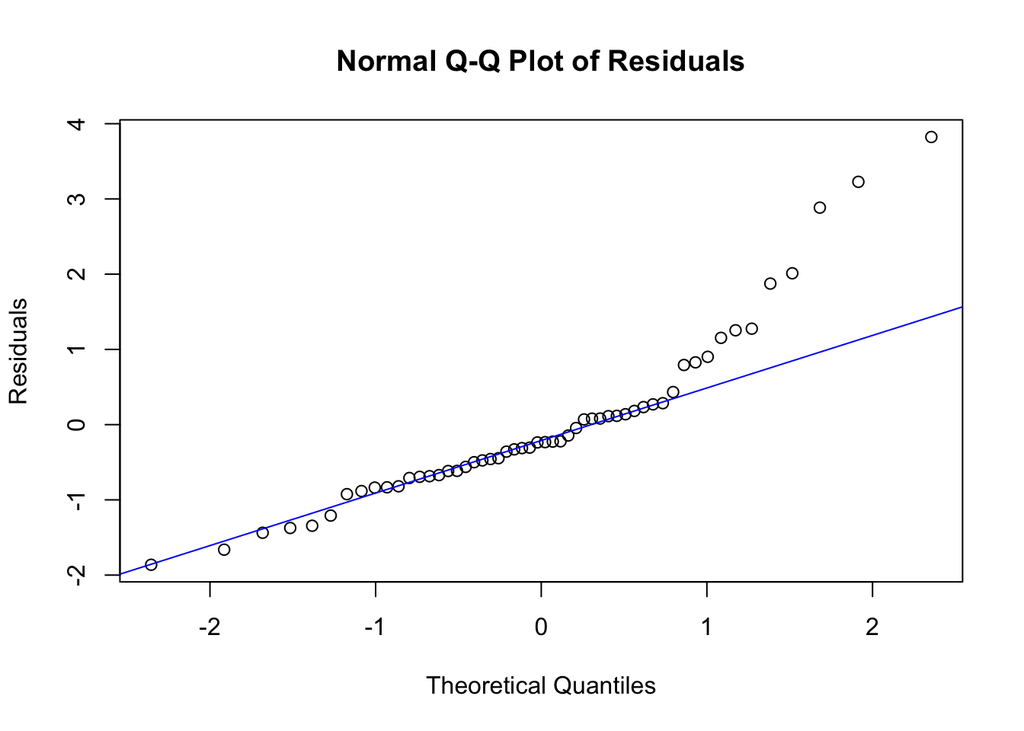

```r
# Ensure coefficients are calculated properly
X <- cbind(1, as.matrix(X))  # Add intercept
residuals <- y - X %*% results$coefficients  # Compute residuals

# Plot the Q-Q plot for residuals
qqnorm(residuals, main = "Normal Q-Q Plot of Residuals",
       ylab = "Residuals", xlab = "Theoretical Quantiles")
qqline(residuals, col = "blue")  # Add a reference line
```

C.) Perform the same regression using the lm() command.

```r
mod <- lm(enps ~ eneth + log_ml + eneth * log_ml, data = cox)
summary(mod)
```

```
##
## Call:
## lm(formula = enps ~ eneth + log_ml + eneth * log_ml, data = cox)
##
## Residuals:
##     Min      1Q  Median      3Q     Max
## -1.8627 -0.6818 -0.2346  0.2605  3.8235
##
## Coefficients:
##              Estimate Std. Error t value Pr(>|t|)
## (Intercept)    2.6714     0.6072   4.399 5.69e-05 ***
## eneth         -0.3620     0.3486  -1.038    0.304
## log_ml        -0.1911     0.2967  -0.644    0.522
## eneth:log_ml   0.4833     0.1805   2.678    0.010 *
## ---
## Signif. codes:  0 '***' 0.001 '**' 0.01 '*' 0.05 '.' 0.1 ' ' 1
##
## Residual standard error: 1.181 on 50 degrees of freedom
## Multiple R-squared:  0.3629, Adjusted R-squared:  0.3247
## F-statistic: 9.493 on 3 and 50 DF,  p-value: 4.541e-05
```

D.) Report the Residual-v.-fitted, Scale-location, and Residual-v.-leverage diagnostic plots for this regression.

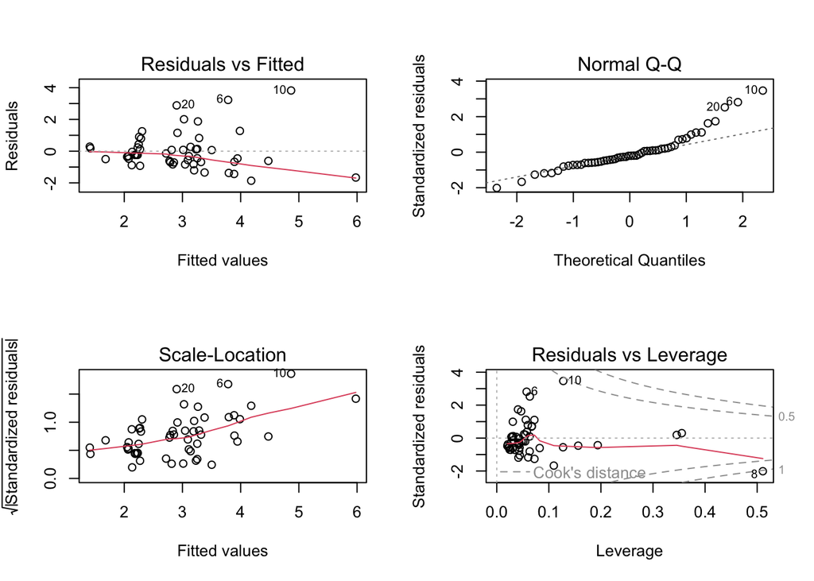

```r
par(mfrow = c(2,2))
plot(mod)
```

E.) Based on these results, is this OLS regression an appropriate model for these data? Provide a paragraph stating why or why not.

In the residual vs. fitted plot, the slight downward curve suggests potential non-linearity. Furthermore, the upward trend in both the Q–Q plot and the Scale-Location plot indicates heteroscedasticity, as the data become more spread out at higher values. There are also a few outliers with large residuals (e.g., observation 10) that could pose problems. If, even after addressing or removing these outliers, the model continues to show signs of heteroscedasticity or non-linearity, then OLS regression may not be the best fit for this dataset.

# Appendix

I used ChatGPT in this assignment. I used the tool to help debug the questions 4b and c as well as break down qusetion 1.https://chatgpt.com/share/6787f91e-a768-8000-8e6c-f1cadd5c1053